# Task1-5

Author

Roman Havrylenko

Published

October 1, 2025

## Question 1 Atomic Types

Create the following variables related to your chosen object:

4 numeric values (e.g., population, temperature, size, rating) 3 integer values (e.g., number of moons, buildings, inhabitants) 2 logical values (e.g., has_water, is_inhabited) 3 character values (e.g., name, region, category)

My object is Poltava city

```r
# code for solving task

#numeric
temperature <- 14.3
meters_above_sea_level <- 140.0
auto <- 285.000
highest_building <- 44.0


# integer

population <- 279593
area <- 103 #m2
shoppin_mall <- 3

#logical

has_water <-TRUE
has_autobus_station <- TRUE

#character

name <- 'Poltava'
region <- 'Poltavsky'
category <- 'city'
```

## Question 2 Vectors

Question description

Create three different vectors:

Numeric vector combining all your numeric and integer variables. (Use c().)

Sequence vector from any number between 10–50 to 100, Choose step between 2 and 10. (Use seq() or :.)

Logical vector of length 10 with random TRUE/FALSE values using sample().

```r
# code for solving task
vec <- c(temperature, meters_above_sea_level, auto, highest_building, population, area, shoppin_mall)

vec
```

```
[1]     14.3    140.0    285.0     44.0 279593.0    103.0      3.0
```

```r
vec_seq <- seq( from = 20, to = 100, by = 6)
vec_seq
```

```
 [1] 20 26 32 38 44 50 56 62 68 74 80 86 92 98
```

```r
vec_log <- sample(c(TRUE, FALSE), 10, replace = TRUE)
vec_log
```

```
 [1] FALSE  TRUE FALSE FALSE  TRUE  TRUE FALSE FALSE FALSE FALSE
```

## Question 3 Marix

Question description

Create a 3×3 matrix with random numbers between -50 and 50 (using sample() or runif()), and name its rows and columns according to your theme.

Then calculate row and column averages using rowMeans() and colMeans().

```r
 # code for solving task
m <- matrix(sample(-50:50, 9), nrow = 3, ncol = 3)
m
```

```
     [,1] [,2] [,3]
[1,]   -7   -5  -28
[2,]  -33  -34  -20
[3,]   34   36  -39
```

```r
rowMeans(m)
```

```
[1] -13.33333 -29.00000  10.33333
```

```r
colMeans(m)
```

```
[1]  -2  -1 -29
```

## Question 4 List

Question description

Create a list that combines all your previous objects: atomic variables, vectors, and matrix. Add one extra element — a short description of your universe as a string.

```r
# code for solving task
list <- list(auto, name, area, has_water, vec, m)
list
```

```
[[1]]
[1] 285

[[2]]
[1] "Poltava"

[[3]]
[1] 103

[[4]]
[1] TRUE

[[5]]
[1]     14.3    140.0    285.0     44.0 279593.0    103.0      3.0

[[6]]
     [,1] [,2] [,3]
[1,]   -7   -5  -28
[2,]  -33  -34  -20
[3,]   34   36  -39
```

## Question 5 Factor

Question description

Create a factor variable representing categories within your universe, e.g.:

```r
# code for solving task

my_factor <- factor(c("big", "big", "small", "medium", "small"), levels = c("small", "medium", "big"))
my_factor
```

```
[1] big    big    small  medium small
Levels: small medium big
```

## Question 6 Data Frame

Question description

Create a data frame related to your object that includes:

5–8 observations (rows) At least 3 columns of different data types (e.g., name, numeric value, logical flag, category) Then:

Rename the columns using names() or colnames(). Display its structure with str() and its summary with summary(). Add a new column derived from the others (for example, a ratio or condition).

```r
data <- data.frame(name=c("centr","podol", "almaznyj", "levada", "mala_scena"), numeric = c(16.4, 14.6, 25.7, 25.1, 18.2), logical = c(T, F, F, T, T), category = c("big", "small", "medium", "medium", "small"))

colnames(data) <- c("name", "size", "has_mall", "size")

data
```

```
        name size has_mall   size
1      centr 16.4     TRUE    big
2      podol 14.6    FALSE  small
3   almaznyj 25.7    FALSE medium
4     levada 25.1     TRUE medium
5 mala_scena 18.2     TRUE  small
```

```r
str(data)
```

```
'data.frame':   5 obs. of  4 variables:
 $ name    : chr  "centr" "podol" "almaznyj" "levada" ...
 $ size    : num  16.4 14.6 25.7 25.1 18.2
 $ has_mall: logi  TRUE FALSE FALSE TRUE TRUE
 $ size    : chr  "big" "small" "medium" "medium" ...
```

```r
summary(data)
```

```
     name                size       has_mall           size
 Length:5           Min.   :14.6   Mode :logical   Length:5
 Class :character   1st Qu.:16.4   FALSE:2         Class :character
 Mode  :character   Median :18.2   TRUE :3         Mode  :character
                    Mean   :20.0
                    3rd Qu.:25.1
                    Max.   :25.7
```

```r
data$size_ratio <- data$size / max(data$size)

data
```

```
        name size has_mall   size size_ratio
1      centr 16.4     TRUE    big  0.6381323
2      podol 14.6    FALSE  small  0.5680934
3   almaznyj 25.7    FALSE medium  1.0000000
4     levada 25.1     TRUE medium  0.9766537
5 mala_scena 18.2     TRUE  small  0.7081712
```

Task 2 2.1. Querying Vectors Let’s start with the vectors you created in Task 1.

2.1.1. From your Sequence vector (the one with all your numbers):

Select and print the 3rd element. Select and print elements 2 through 5. Select and print all values that are greater than 20 (or another number that makes sense for your data). 2.1.2. From your Logical vector:

Select and print only the TRUE values. (Hint: your_vector[your_vector]). Use which() to get the indices (positions) of all the TRUE values.

```r
vec_seq[3]
```

```
[1] 32
```

```r
vec_seq[2:5]
```

```
[1] 26 32 38 44
```

```r
vec_seq[vec_seq > 20]
```

```
 [1] 26 32 38 44 50 56 62 68 74 80 86 92 98
```

```r
vec_log[vec_log]
```

```
[1] TRUE TRUE TRUE
```

```r
which(vec_log)
```

```
[1] 2 5 6
```

2.3. Investigating Your Data Frame Use the data frame you created in Task 1.

Print the first 3 rows. (Use head().) Print the value from the 4th row, 1st column. Print only the column that contains your logical values (e.g., is_habitable) as a vector. Logical Subsetting: Create a new data frame df_subset that contains only the rows that meet a specific logical condition.

Example: df_subset <- your_df[your_df$population > 1000, ] %in% Subsetting: Create a new data frame df_subset_2 that selects rows belonging to two specific categories from your factor or character column.

Example: df_subset_2 <- your_df[your_df$region %in% c(“North”, “South”), ]

```r
head(data, 3)
```

```
      name size has_mall   size size_ratio
1    centr 16.4     TRUE    big  0.6381323
2    podol 14.6    FALSE  small  0.5680934
3 almaznyj 25.7    FALSE medium  1.0000000
```

```r
data [4, 1]
```

```
[1] "levada"
```

```r
data$has_mall
```

```
[1]  TRUE FALSE FALSE  TRUE  TRUE
```

```r
df_subset <- data[data$size > 20, ]
df_subset
```

```
      name size has_mall   size size_ratio
3 almaznyj 25.7    FALSE medium  1.0000000
4   levada 25.1     TRUE medium  0.9766537
```

```r
df_subset_2 <- data[data$category %in% c("small", "medium"), ]
df_subset_2
```

```
[1] name       size       has_mall   size       size_ratio
<0 строк> (или 'row.names' нулевой длины)
```

2.4. Handling “Corrupted” Data (NA) Create a copy of your original data frame (e.g., df_corrupted <- your_df).

Introduce 3 NAs into your df_corrupted at specific locations.

Example: df_corrupted[2, 3] <- NA Find NAs:

Use sum(is.na(df_corrupted)) to find the total number of missing values. Use colSums(is.na(df_corrupted)) to see how many NAs are in each column. Calculate with NAs:

Calculate the mean() of the numeric column where you added an NA. Filter NAs:

Use na.omit(df_corrupted) to create a new, “clean” data frame that contains only the complete rows.

```r
df_corrupted <- data

df_corrupted[2, 2] <- NA
df_corrupted[5, 3] <- NA
df_corrupted[3, 4] <- NA

df_corrupted
```

```
        name size has_mall   size size_ratio
1      centr 16.4     TRUE    big  0.6381323
2      podol   NA    FALSE  small  0.5680934
3   almaznyj 25.7    FALSE   <NA>  1.0000000
4     levada 25.1     TRUE medium  0.9766537
5 mala_scena 18.2       NA  small  0.7081712
```

```r
sum(is.na(df_corrupted))
```

```
[1] 3
```

```r
colSums(is.na(df_corrupted))
```

```
      name       size   has_mall       size size_ratio
         0          1          1          1          0
```

```r
mean(df_corrupted$size)
```

```
[1] NA
```

```r
mean(df_corrupted$size, na.rm = TRUE)
```

```
[1] 21.35
```

```r
df_clean <- na.omit(df_corrupted)
df_clean
```

```
    name size has_mall   size size_ratio
1  centr 16.4     TRUE    big  0.6381323
4 levada 25.1     TRUE medium  0.9766537
```

2.5. Bonus Challenge: which() Use which.max() or which.min() to find the row number (index) of the observation with the highest or lowest value in one of your numeric columns.

Use that index to print the row with that observation.

Example: highest_pop_index <- which.max(your_df$population) Example: your_df[highest_pop_index, ]

```r
highest_size_index <- which.max(data$size)
data[highest_size_index, ]
```

```
      name size has_mall   size size_ratio
3 almaznyj 25.7    FALSE medium          1
```

```r
lowest_size_index <- which.min(data$size)
data[lowest_size_index, ]
```

```
   name size has_mall  size size_ratio
2 podol 14.6    FALSE small  0.5680934
```

3.1. The Quest: Find Your Data Find one simple, real-world dataset that fits your theme.

Where to look: Kaggle, TidyTuesday, data.gov, or other public data portals.

Format: Any format you are able to read. For simplicity it is proposed to use textual (csv, txt) or Excel format.

Requirements:

At least 50 rows.

At least 4 columns.

A mix of numeric and character/factor data.

Action:

Download the data file and place it in your R project directory.

In your task file add a line with the link to the data source (e.g., Data from: https://…).

```r
# Data from: https://www.kaggle.com/datasets/dgomonov/new-york-city-airbnb-open-data
```

3.2. The Import: Load Your Data

Install tidyverse: If you haven’t, run install.packages(“tidyverse”) in your console (just once).

Load libraries: At the top of your script, add library(dplyr) and library(readr) (library(readxl) in case of Excel file format).

Read the data: Use read_csv() (or read_excel()) to load your dataset into a new data frame.

# Load the Tidyverse libraries

library(dplyr) library(readr)

# Load your data

data <- read_csv(“AB_NYC_2019.csv”)

First Inspection: Immediately after loading, inspect your data to make sure it loaded correctly. # See the structure and column types glimpse(data)

# See the first 6 rows

head(data)

# Get a statistical summary

summary(data)

```r
# Install (only once)
# install.packages("tidyverse")

library(dplyr)
library(readr)
# Load dataset
data <- read_csv("AB_NYC_2019.csv")
# First inspection
glimpse(data)
```

```
Rows: 48,895
Columns: 16
$ id                             <dbl> 2539, 2595, 3647, 3831, 5022, 5099, 512…
$ name                           <chr> "Clean & quiet apt home by the park", "…
$ host_id                        <dbl> 2787, 2845, 4632, 4869, 7192, 7322, 735…
$ host_name                      <chr> "John", "Jennifer", "Elisabeth", "LisaR…
$ neighbourhood_group            <chr> "Brooklyn", "Manhattan", "Manhattan", "…
$ neighbourhood                  <chr> "Kensington", "Midtown", "Harlem", "Cli…
$ latitude                       <dbl> 40.64749, 40.75362, 40.80902, 40.68514,…
$ longitude                      <dbl> -73.97237, -73.98377, -73.94190, -73.95…
$ room_type                      <chr> "Private room", "Entire home/apt", "Pri…
$ price                          <dbl> 149, 225, 150, 89, 80, 200, 60, 79, 79,…
$ minimum_nights                 <dbl> 1, 1, 3, 1, 10, 3, 45, 2, 2, 1, 5, 2, 4…
$ number_of_reviews              <dbl> 9, 45, 0, 270, 9, 74, 49, 430, 118, 160…
$ last_review                    <date> 2018-10-19, 2019-05-21, NA, 2019-07-05…
$ reviews_per_month              <dbl> 0.21, 0.38, NA, 4.64, 0.10, 0.59, 0.40,…
$ calculated_host_listings_count <dbl> 6, 2, 1, 1, 1, 1, 1, 1, 1, 4, 1, 1, 3, …
$ availability_365               <dbl> 365, 355, 365, 194, 0, 129, 0, 220, 0, …
```

```r
head(data)
```

```
# A tibble: 6 × 16
     id name        host_id host_name neighbourhood_group neighbourhood latitude
  <dbl> <chr>         <dbl> <chr>     <chr>               <chr>            <dbl>
1  2539 Clean & qu…    2787 John      Brooklyn            Kensington        40.6
2  2595 Skylit Mid…    2845 Jennifer  Manhattan           Midtown           40.8
3  3647 THE VILLAG…    4632 Elisabeth Manhattan           Harlem            40.8
4  3831 Cozy Entir…    4869 LisaRoxa… Brooklyn            Clinton Hill      40.7
5  5022 Entire Apt…    7192 Laura     Manhattan           East Harlem       40.8
6  5099 Large Cozy…    7322 Chris     Manhattan           Murray Hill       40.7
# ℹ 9 more variables: longitude <dbl>, room_type <chr>, price <dbl>,
#   minimum_nights <dbl>, number_of_reviews <dbl>, last_review <date>,
#   reviews_per_month <dbl>, calculated_host_listings_count <dbl>,
#   availability_365 <dbl>
```

```r
summary(data)
```

```
       id               name              host_id           host_name
 Min.   :    2539   Length:48895       Min.   :     2438   Length:48895
 1st Qu.: 9471945   Class :character   1st Qu.:  7822033   Class :character
 Median :19677284   Mode  :character   Median : 30793816   Mode  :character
 Mean   :19017143                      Mean   : 67620011
 3rd Qu.:29152178                      3rd Qu.:107434423
 Max.   :36487245                      Max.   :274321313

 neighbourhood_group neighbourhood         latitude       longitude
 Length:48895        Length:48895       Min.   :40.50   Min.   :-74.24
 Class :character    Class :character   1st Qu.:40.69   1st Qu.:-73.98
 Mode  :character    Mode  :character   Median :40.72   Median :-73.96
                                        Mean   :40.73   Mean   :-73.95
                                        3rd Qu.:40.76   3rd Qu.:-73.94
                                        Max.   :40.91   Max.   :-73.71

  room_type             price         minimum_nights    number_of_reviews
 Length:48895       Min.   :    0.0   Min.   :   1.00   Min.   :  0.00
 Class :character   1st Qu.:   69.0   1st Qu.:   1.00   1st Qu.:  1.00
 Mode  :character   Median :  106.0   Median :   3.00   Median :  5.00
                    Mean   :  152.7   Mean   :   7.03   Mean   : 23.27
                    3rd Qu.:  175.0   3rd Qu.:   5.00   3rd Qu.: 24.00
                    Max.   :10000.0   Max.   :1250.00   Max.   :629.00

  last_review         reviews_per_month calculated_host_listings_count
 Min.   :2011-03-28   Min.   : 0.010    Min.   :  1.000
 1st Qu.:2018-07-08   1st Qu.: 0.190    1st Qu.:  1.000
 Median :2019-05-19   Median : 0.720    Median :  1.000
 Mean   :2018-10-04   Mean   : 1.373    Mean   :  7.144
 3rd Qu.:2019-06-23   3rd Qu.: 2.020    3rd Qu.:  2.000
 Max.   :2019-07-08   Max.   :58.500    Max.   :327.000
 NA's   :10052        NA's   :10052
 availability_365
 Min.   :  0.0
 1st Qu.:  0.0
 Median : 45.0
 Mean   :112.8
 3rd Qu.:227.0
 Max.   :365.0
```

3.3. The Interrogation: Explore with dplyr This is the core of the task. Your goal is to ask and answer 5 interesting questions about your new dataset.

You must write the question in plain English (as a comment), followed by the dplyr code that answers it.

You must use each of the following dplyr “verbs” at least once:

select() - To pick specific columns.

filter() - To subset rows based on a condition.

arrange() - To sort your results (e.g., with desc()).

mutate() - To create a new column.

group_by() and summarise() - To get summary statistics (like mean(), n(), max(), etc.).

```r
# Question 1:
# Which neighbourhood groups have the highest average price?
data %>%
  group_by(neighbourhood_group) %>%
  summarise(avg_price = mean(price, na.rm = TRUE)) %>%
  arrange(desc(avg_price))
```

```
# A tibble: 5 × 2
  neighbourhood_group avg_price
  <chr>                   <dbl>
1 Manhattan               197.
2 Brooklyn                124.
3 Staten Island           115.
4 Queens                   99.5
5 Bronx                    87.5
```

```r
# Question 2:
# Which 10 ads are the most expensive?
data %>%
  select(name, host_id, neighbourhood, price) %>%
  arrange(desc(price)) %>%
  head(10)
```

```
# A tibble: 10 × 4
   name                                              host_id neighbourhood price
   <chr>                                               <dbl> <chr>         <dbl>
 1 Furnished room in Astoria apartment                2.06e7 Astoria       10000
 2 Luxury 1 bedroom apt. -stunning Manhattan views    5.14e6 Greenpoint    10000
 3 1-BR Lincoln Center                                7.24e7 Upper West S… 10000
 4 Spanish Harlem Apt                                 1.24e6 East Harlem    9999
 5 Quiet, Clean, Lit @ LES & Chinatown                3.91e6 Lower East S…  9999
 6 2br - The Heart of NYC: Manhattans Lower East Si…  4.38e6 Lower East S…  9999
 7 Beautiful/Spacious 1 bed luxury flat-TriBeCa/Soho  1.81e7 Tribeca        8500
 8 Film Location                                      1.18e6 Clinton Hill   8000
 9 East 72nd Townhouse by (Hidden by Airbnb)          1.56e8 Upper East S…  7703
10 70' Luxury MotorYacht on the Hudson                7.41e6 Battery Park…  7500
```

```r
# Question 3:
# How many listings are there for each room type (room_type)?
data %>%
  group_by(room_type) %>%
  summarise(count = n())
```

```
# A tibble: 3 × 2
  room_type       count
  <chr>           <int>
1 Entire home/apt 25409
2 Private room    22326
3 Shared room      1160
```

```r
# Question 4:
# Add a new column “price_per_minimum_stay” = price / minimum_nights.
# Show the first 10 rows.
data %>%
  filter(minimum_nights > 0, price > 0) %>%
  mutate(price_per_minimum_stay = price / minimum_nights) %>%
  select(name, neighbourhood_group, price, minimum_nights, price_per_minimum_stay) %>%
  head(10)
```

```
# A tibble: 10 × 5
   name          neighbourhood_group price minimum_nights price_per_minimum_stay
   <chr>         <chr>               <dbl>          <dbl>                  <dbl>
 1 Clean & quie… Brooklyn              149              1                 149
 2 Skylit Midto… Manhattan             225              1                 225
 3 THE VILLAGE … Manhattan             150              3                  50
 4 Cozy Entire … Brooklyn               89              1                  89
 5 Entire Apt: … Manhattan              80             10                   8
 6 Large Cozy 1… Manhattan             200              3                  66.7
 7 BlissArtsSpa… Brooklyn               60             45                   1.33
 8 Large Furnis… Manhattan              79              2                  39.5
 9 Cozy Clean G… Manhattan              79              2                  39.5
10 Cute & Cozy … Manhattan             150              1                 150
```

```r
# Question 5:
# Filter: listings in Manhattan over $200 with a minimum of 3 nights.
data %>%
  filter(neighbourhood_group == "Manhattan",
         price > 200,
         minimum_nights >= 3) %>%
  select(name, neighbourhood, price, minimum_nights)
```

```
# A tibble: 3,459 × 4
   name                                       neighbourhood price minimum_nights
   <chr>                                      <chr>         <dbl>          <dbl>
 1 Sunny & Spacious Chelsea Apartment         Chelsea         375            180
 2 SpaHa Loft: Enormous and Bright            East Harlem     225              4
 3 Lovely EV Artist's Home                    East Village    230              9
 4 Entire 2 Bedroom - Large & Sunny           Lower East S…   285              5
 5 2000 SF 3br 2bath West Village private  t… West Village    500              4
 6 Comfortable UWS 2-BD Family-Friendly Brow… Upper West S…   235              6
 7 Sunny, clean 1 bdrm in W. Village          West Village    225             45
 8 Light and Airy Upper East Side 1 BDR apar… Upper East S…   219              4
 9 Charming & Cozy midtown loft any WEEK END… Upper East S…   250              3
10 Great new apt, close to everything         Hell's Kitch…   250              3
# ℹ 3,449 more rows
```

Task 4. Building a “Toolkit” for Your Universe (Functions)

4.1. The “Greeting” Function (A Simple Start) Let’s start with the basics. Write a simple function that prints a welcome message for your “universe”.

Write the function: It should take at least one argument (e.g., your_name or universe_name).

Inside the function: Use print() or cat() to display a message.

Call the function: After you define the function, you must call it to see the result.

```r
welcome_to_my_universe <- function(Roman) {
  cat("------------------------------------\n")
  cat("Analysis Toolkit for PPFK\n")
  cat("Report prepared by: Roman \n")
  cat("------------------------------------\n")
}

# Вызов
welcome_to_my_universe("PPFK")
```

```
------------------------------------
Analysis Toolkit for PPFK
Report prepared by: Roman
------------------------------------
```

4.2. The “Loading” Function (A Good Practice) In Task 3, you wrote code to load and inspect your data. Let’s turn that into a function. This is a very common and useful practice.

Write the function: Name it load_and_inspect. It should take one argument: file_path.

Inside the function:

Load the readr and dplyr libraries.

Use read_csv(file_path) to load the data.

Print a message (e.g., “Data loaded successfully.”).

Print the glimpse() of the data.

Print the head() of the data.

Return the data frame (use the return() command).

Call the function:

```r
library(readr)
library(dplyr)

load_and_inspect <- function(file_path) {

  data <- read_csv(file_path)

  cat("\n✔ Data Loaded:", file_path, "\n")
  print(glimpse(data))

  cat("\n--- First 6 rows ---\n")
  print(head(data))

  return(data)
}

# Call the function, saving its output to a variable
data <- load_and_inspect("C:/Users/roomg/OneDrive/Рабочий стол/AB_NYC_2019.csv")
```

```
✔ Data Loaded: C:/Users/roomg/OneDrive/Рабочий стол/AB_NYC_2019.csv
Rows: 48,895
Columns: 16
$ id                             <dbl> 2539, 2595, 3647, 3831, 5022, 5099, 512…
$ name                           <chr> "Clean & quiet apt home by the park", "…
$ host_id                        <dbl> 2787, 2845, 4632, 4869, 7192, 7322, 735…
$ host_name                      <chr> "John", "Jennifer", "Elisabeth", "LisaR…
$ neighbourhood_group            <chr> "Brooklyn", "Manhattan", "Manhattan", "…
$ neighbourhood                  <chr> "Kensington", "Midtown", "Harlem", "Cli…
$ latitude                       <dbl> 40.64749, 40.75362, 40.80902, 40.68514,…
$ longitude                      <dbl> -73.97237, -73.98377, -73.94190, -73.95…
$ room_type                      <chr> "Private room", "Entire home/apt", "Pri…
$ price                          <dbl> 149, 225, 150, 89, 80, 200, 60, 79, 79,…
$ minimum_nights                 <dbl> 1, 1, 3, 1, 10, 3, 45, 2, 2, 1, 5, 2, 4…
$ number_of_reviews              <dbl> 9, 45, 0, 270, 9, 74, 49, 430, 118, 160…
$ last_review                    <date> 2018-10-19, 2019-05-21, NA, 2019-07-05…
$ reviews_per_month              <dbl> 0.21, 0.38, NA, 4.64, 0.10, 0.59, 0.40,…
$ calculated_host_listings_count <dbl> 6, 2, 1, 1, 1, 1, 1, 1, 1, 4, 1, 1, 3, …
$ availability_365               <dbl> 365, 355, 365, 194, 0, 129, 0, 220, 0, …
# A tibble: 48,895 × 16
      id name       host_id host_name neighbourhood_group neighbourhood latitude
   <dbl> <chr>        <dbl> <chr>     <chr>               <chr>            <dbl>
 1  2539 Clean & q…    2787 John      Brooklyn            Kensington        40.6
 2  2595 Skylit Mi…    2845 Jennifer  Manhattan           Midtown           40.8
 3  3647 THE VILLA…    4632 Elisabeth Manhattan           Harlem            40.8
 4  3831 Cozy Enti…    4869 LisaRoxa… Brooklyn            Clinton Hill      40.7
 5  5022 Entire Ap…    7192 Laura     Manhattan           East Harlem       40.8
 6  5099 Large Coz…    7322 Chris     Manhattan           Murray Hill       40.7
 7  5121 BlissArts…    7356 Garon     Brooklyn            Bedford-Stuy…     40.7
 8  5178 Large Fur…    8967 Shunichi  Manhattan           Hell's Kitch…     40.8
 9  5203 Cozy Clea…    7490 MaryEllen Manhattan           Upper West S…     40.8
10  5238 Cute & Co…    7549 Ben       Manhattan           Chinatown         40.7
# ℹ 48,885 more rows
# ℹ 9 more variables: longitude <dbl>, room_type <chr>, price <dbl>,
#   minimum_nights <dbl>, number_of_reviews <dbl>, last_review <date>,
#   reviews_per_month <dbl>, calculated_host_listings_count <dbl>,
#   availability_365 <dbl>

--- First 6 rows ---
# A tibble: 6 × 16
     id name        host_id host_name neighbourhood_group neighbourhood latitude
  <dbl> <chr>         <dbl> <chr>     <chr>               <chr>            <dbl>
1  2539 Clean & qu…    2787 John      Brooklyn            Kensington        40.6
2  2595 Skylit Mid…    2845 Jennifer  Manhattan           Midtown           40.8
3  3647 THE VILLAG…    4632 Elisabeth Manhattan           Harlem            40.8
4  3831 Cozy Entir…    4869 LisaRoxa… Brooklyn            Clinton Hill      40.7
5  5022 Entire Apt…    7192 Laura     Manhattan           East Harlem       40.8
6  5099 Large Cozy…    7322 Chris     Manhattan           Murray Hill       40.7
# ℹ 9 more variables: longitude <dbl>, room_type <chr>, price <dbl>,
#   minimum_nights <dbl>, number_of_reviews <dbl>, last_review <date>,
#   reviews_per_month <dbl>, calculated_host_listings_count <dbl>,
#   availability_365 <dbl>
```

4.3. The “Query” Function (The Core of the Task) This is the most important step. You will turn one of your dplyr queries from Task 3 into a reusable function.

Look back at your Task 3 code. You probably wrote something like this:

data |> filter(population > 1000000)

data |> filter(planet_type == “Gas Giant”)

That 1000000 or “Gas Giant” is a “magic number” or “magic string”. A function lets you turn it into a parameter.

Choose a query: Pick one of your filter() or summarise() queries from Task 3.

Write the function:

Give it a descriptive name (e.g., find_pollution_by_disctrict, filter_cities_by_population).

It must take at least two arguments: data (for the data frame) and a parameter for the value you want to change (e.g., pop_threshold or type_name).

The function should perform the dplyr query and return the result.

```r
filter_by_area_and_price <- function(data, area_name, max_price) {

  result <- data |>
    filter(neighbourhood_group == area_name) |>
    filter(price <= max_price)

  return(result)
}

cheap_manhattan <- filter_by_area_and_price(data, "Manhattan", 100)

print(cheap_manhattan)
```

```
# A tibble: 6,921 × 16
      id name       host_id host_name neighbourhood_group neighbourhood latitude
   <dbl> <chr>        <dbl> <chr>     <chr>               <chr>            <dbl>
 1  5022 Entire Ap…    7192 Laura     Manhattan           East Harlem       40.8
 2  5178 Large Fur…    8967 Shunichi  Manhattan           Hell's Kitch…     40.8
 3  5203 Cozy Clea…    7490 MaryEllen Manhattan           Upper West S…     40.8
 4  5441 Central M…    7989 Kate      Manhattan           Hell's Kitch…     40.8
 5  6021 Wonderful…   11528 Claudio   Manhattan           Upper West S…     40.8
 6  8700 Magnifiqu…   26394 Claude &… Manhattan           Inwood            40.9
 7  9518 SPACIOUS,…   31374 Shon      Manhattan           Inwood            40.9
 8  9668 front roo…   32294 Ssameer … Manhattan           Harlem            40.8
 9  9704 Spacious …   32045 Teri      Manhattan           Harlem            40.8
10  9783 back room…   32294 Ssameer … Manhattan           Harlem            40.8
# ℹ 6,911 more rows
# ℹ 9 more variables: longitude <dbl>, room_type <chr>, price <dbl>,
#   minimum_nights <dbl>, number_of_reviews <dbl>, last_review <date>,
#   reviews_per_month <dbl>, calculated_host_listings_count <dbl>,
#   availability_365 <dbl>
```

4.4. The “Reporting” Function Let’s combine everything. Write a single function that calculates several key statistics for a specific group or category in your data.

Write the function: Name it generate_report. It should take data and a category_name as arguments (e.g., a specific city, planet type, or region).

Inside the function:

filter() your data for only the category_name provided.

Calculate 3-4 interesting summary statistics (e.g., mean(), max(), min(), n()).

Use cat() to print a nicely formatted “report” to the console.

```r
generate_report <- function(data, area_name) {

  area_data <- data |>
    filter(neighbourhood_group == area_name)

  n_listings <- nrow(area_data)
  avg_price <- mean(area_data$price, na.rm = TRUE)
  min_price <- min(area_data$price, na.rm = TRUE)
  max_price <- max(area_data$price, na.rm = TRUE)
  avg_reviews <- mean(area_data$number_of_reviews, na.rm = TRUE)

  cat("\n----------- Report for:", area_name, "-----------\n")
  cat("Total Listings:", n_listings, "\n")
  cat("Average Price:", round(avg_price, 2), "\n")
  cat("Minimum Price:", min_price, "\n")
  cat("Maximum Price:", max_price, "\n")
  cat("Average Number of Reviews:", round(avg_reviews, 2), "\n")
  cat("-----------------------------------------------\n\n")
}

generate_report(data, "Manhattan")
```

```
----------- Report for: Manhattan -----------
Total Listings: 21661
Average Price: 196.88
Minimum Price: 0
Maximum Price: 10000
Average Number of Reviews: 20.99
-----------------------------------------------
```

```r
generate_report(data, "Brooklyn")
```

```
----------- Report for: Brooklyn -----------
Total Listings: 20104
Average Price: 124.38
Minimum Price: 0
Maximum Price: 10000
Average Number of Reviews: 24.2
-----------------------------------------------
```

Task 5. Visualising Your Universe (Base R & ggplot2) You have found your data (Task 3) and built tools to analyse it (Task 4). Now, you must present your findings to customers.

Your goal is to create four specific visualizations based on the real-world dataset you imported in Task 3.

Prerequisites:

Use the dataset you found and cleaned in Task 3.

Make sure library(ggplot2) is loaded.

Crucial: Every plot must have a Title, x-axis label, and y-axis label that make sense for your specific theme.

5.1. The Quick Sketch (Base R Histogram) Sometimes you need a quick look at the distribution of your data without loading heavy packages.

Choose one numeric variable from your dataset (e.g., price, temperature, speed).

Use the hist() function from base R.

Customise the main title, xlab, and the bar col (colour).

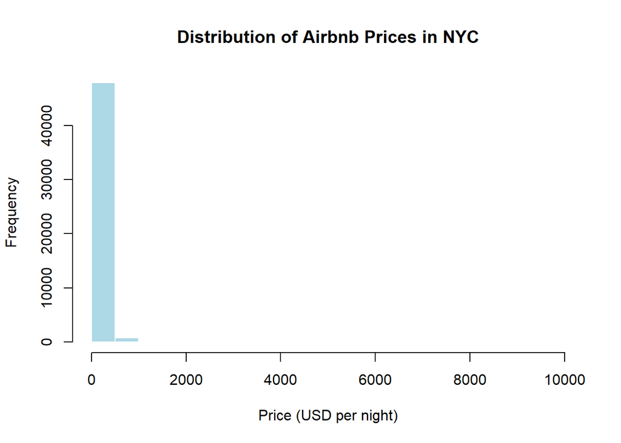

```r
library(dplyr)
library(readr)
library(ggplot2)
hist(data$price,
     main = "Distribution of Airbnb Prices in NYC",
     xlab = "Price (USD per night)",
     col = "lightblue",
     border = "white")
```

5.2. The Relationship Map (ggplot2 Scatter Plot) Now, let’s look for patterns using the industry-standard package, ggplot2.

Choose two numeric variables to see if they are correlated.

Create a scatter plot using geom_point().

Add geom_smooth() to add a relationship between variables to the plot.

Add labs() to rename your axes and title.

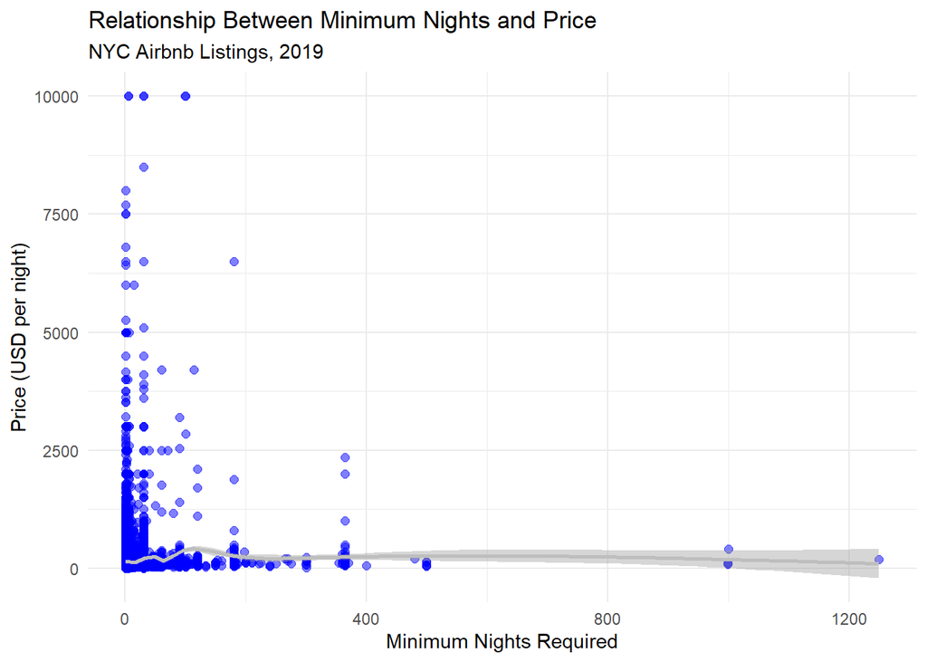

```r
ggplot(data = data, aes(x = minimum_nights, y = price)) +
  geom_point(alpha = 0.5, size = 2, colour = "blue") +
  geom_smooth(color = "gray") +
  labs(
    title = "Relationship Between Minimum Nights and Price",
    subtitle = "NYC Airbnb Listings, 2019",
    x = "Minimum Nights Required",
    y = "Price (USD per night)"
  ) +
  theme_minimal()
```

5.3. The Comparison (ggplot2 Boxplot) The Comparison (ggplot2 Boxplot) Boxplots are excellent for comparing groups. Let’s see how different categories in your universe perform.

Choose a categorical (or logical) variable for the X-axis (e.g., city, planet_type, species).

Choose a numeric variable for the Y-axis (e.g., price, gravity, lifespan).

Create a plot using geom_boxplot().

Bonus: Use fill to colour the boxes by the same category.

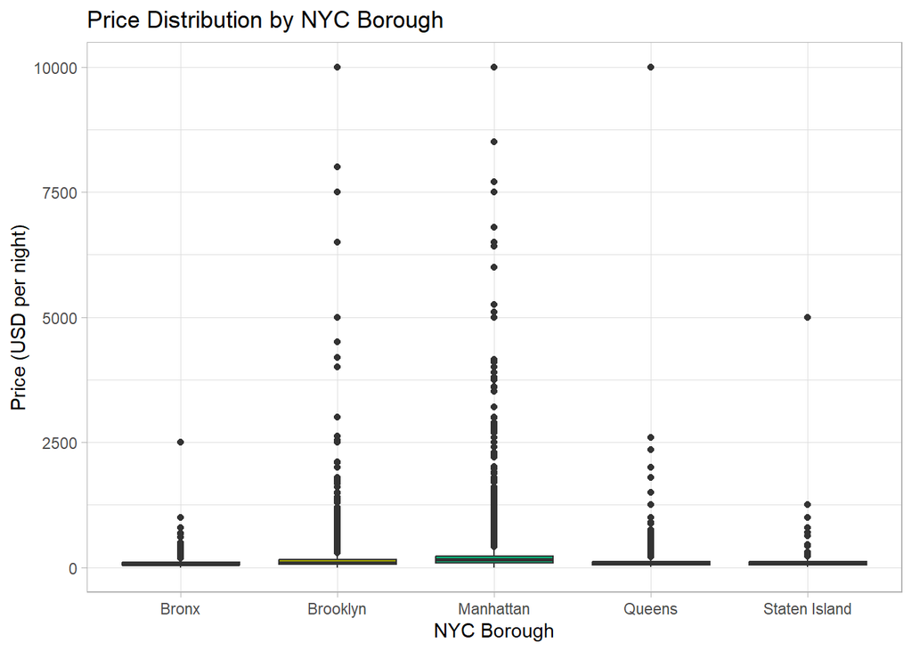

```r
ggplot(data = data, aes(x = neighbourhood_group, y = price, fill = neighbourhood_group)) +
  geom_boxplot() +
  labs(
    title = "Price Distribution by NYC Borough",
    x = "NYC Borough",
    y = "Price (USD per night)"
  ) +
  theme_light() +
  theme(legend.position = "none")
```

5.4. The “Deep Dive” (Faceting or Custom) The most powerful feature of ggplot2 is faceting—creating small multiples of the same plot for different groups.

Create a plot (histogram, bar plot, or scatter plot).

Use facet_wrap(~ your_category_variable) to split the plot into a separate panel for each group in your data.

This is incredibly useful for comparing distinct groups (e.g., separate charts for each City or Year).

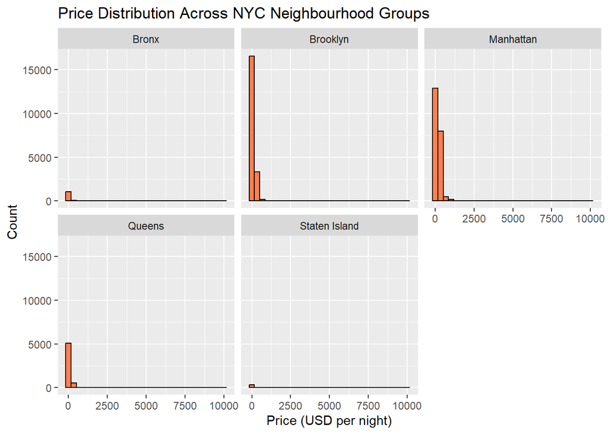

```r
ggplot(data = data, aes(x = price)) +
  geom_histogram(bins = 30, fill = "coral", color = "black") +
  facet_wrap(~ neighbourhood_group) +
  labs(
    title = "Price Distribution Across NYC Neighbourhood Groups",
    x = "Price (USD per night)",
    y = "Count"
  )
```

5.5. Final Step: Exporting (Saving Your Work) A plot is useless if you can’t put it in a report.

Choose your favourite plot from the exercises above.

Run the code to display it in R.

Immediately run the following command to save it to your project folder:

```r
ggsave("nyc_airbnb_price_boxplot.png", width = 8, height = 6)
```